# Project1

Sneha Karanjai

9/11/2022

# Introduction

The goal of this document is to walk you through the process of data processing and manipulation of data from the census bureau. The document will be divided into multiple sections to explain each part of data manipulation and finally, there will be a section combining everything into seamless function calls.

# Dataset

We use a number of different files from the census bureau. The datasets are .csv files and are a little older (2010). The files that we will be working with are :

- EDU01a.csv
- EDU01b.csv
- PST01a.csv
- PST01b.csv
- PST01c.csv
- PST01d.csv

# Libraries

We start by installing and importing the necessary libraries. The libraries used in this document are :

- `readr` : The goal of ‘readr’ is to provide a fast and friendly way to read rectangular data (like ‘csv’, ‘tsv’, and ‘fwf’). It is designed to flexibly parse many types of data found in the wild, while still cleanly failing when data unexpectedly changes.
- `tidyverse` : The ‘tidyverse’ is a set of packages that work in harmony because they share common data representations and ‘API’ design. This package is designed to make it easy to install and load multiple ‘tidyverse’ packages in a single step.

```r
install.packages("readr")
install.packages("tidyverse")
```

We then use the `library()` function to read the packages into the R environment.

```r
library(readr)
library(tidyverse)
```

# Data Processing

Let us look at the flow of the data processing :

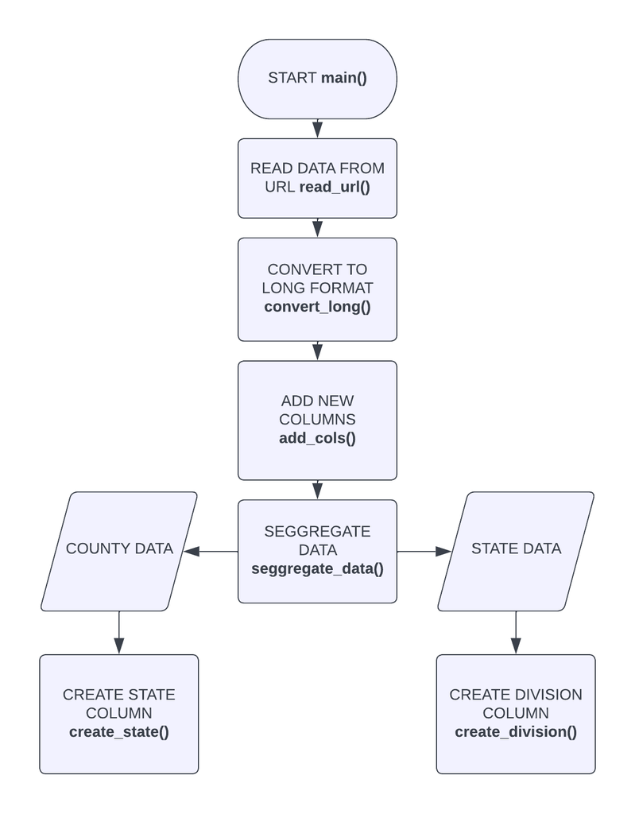

The first step in data processing is to read the dataset. We will write a function that reads in the dataset from the URL provided. We use the `read_csv()` function from the `readr` package to do so. It is particularly useful for reading the most common types of flat file data, comma-separated values.

```r
#function to take the URL and return a tibble
read_url <- function(url){
  data <- read_csv(url) %>%
    as_tibble
  return(data)
}
```

Once we have the data read into the R environment as a tibble, it is time for us to start performing data processing activities. A dataset will have multiple columns but we will select only the ones that are useful for the analysis purpose. We use the `select()` function from the `dplyr` package. `select()` keeps only the variables you mention and `rename()` changes the names of individual variables. We will change `Area_name` to `area_name`. We then convert this data to a long format that is the most common format for data analysis. We require each row to have only one enrollment value for that Area_name. `tidyr` provides a function called `pivot_longer()` that takes a wide format data and converts it into long format. We convert the enrollment values to a column called code. We notice that the enrollment values end with “D” so we use the `ends_with()` function to achieve this.

```r
# function to pre-process data
convert_long <- function(data, var_name){
  return(data %>%
           rename(area_name = Area_name) %>%
           select(c(area_name,
                    STCOU,
                    ends_with("D"))) %>%
           pivot_longer(cols = ends_with("D"),
                        values_to = var_name,
                        names_to = "code"))
}
```

We now extract years from the code. Since we only have the last two digits of the year, we need a couple of base R functions to get the year with the century. We also add a new column called measurement which is extracted from the existing code column. We extensively use `substr()` and `str_sub()` from base R package and stringr package respectively. The difference between the two functions is `str_sub()` will recycle all arguments to be the same length as the longest argument. If any arguments are of length 0, the output will be a zero-length character vector whereas `substr()` will only extract or replace substrings in a character vector.

```r
# adding a new column from the existing column values
add_cols <- function(new_data){
  return(new_data %>%
           mutate(year = as.numeric(format(
             as.Date(str_sub(new_data$code, start= -3) %>%
                       str_sub(1, 2), format = "%y"), "%Y")),
                  measurement = substr(new_data$code, 1, 7)))
}
```

Now that we have manipulated the data to get it in the desirable format. We now split the data by county-level and state-level information. We do this by looking at the regex pattern of the column area_name. All the rows that have area_name in the format “County Name, DD”. We use base R’s `grep()` package for pattern matching.`grep()` gives indexes that match the pattern. We use `-` to get the other indexes and store these two results in separate data frames. We add a state column in the county dataset and a division column which is conditional in the state dataset. We also overwrite the classes of these two datasets.

```r
# extract state
create_state <- function(county_data) {
  # county level
  return(county_data %>%
           mutate(state = str_sub(area_name, start = -2)))
}
```

```r
# get division column
division_1 <- c("connecticut", "maine", "massachusetts", "new hampshire", "rhode island", "Vermont")
division_2 <- c("new jersey", "new york", "pennsylvania")
division_3 <- c("illinois", "indiana", "michigan", "ohio", "wisconsin")
division_4 <- c("iowa", "kansas", "minnesota", "missouri", "nebraska", "north dakota", "south dakota")
division_5 <- c("delaware", "florida", "georgia", "maryland", "north carolina", "south carolina", "virginia", "washington d.c.", "west virginia")
division_6 <- c("alabama", "kentucky", "mississippi", "tennessee")
division_7 <- c("arkansas", "louisiana", "oklahoma", "texas")
division_8 <- c("arizona", "colorado", "idaho", "montana", "nevada", "new mexico", "utah", "Wyoming")
division_9 <- c("alaska", "california", "hawaii", "oregon", "washington")
create_division <- function(non_county_data) {
  # non-county level
  non_county_data$division <- NA
  for (i in 1:nrow(non_county_data)){
    if (tolower(non_county_data$area_name[i]) %in% division_1){
      non_county_data$division[i] = "Division 1"
    }
    else if(tolower(non_county_data$area_name[i]) %in% division_2){
      non_county_data$division[i] = "Division 2"
    }
    else if(tolower(non_county_data$area_name[i]) %in%  division_3){
      non_county_data$division[i] = "Division 3"
    }
    else if(tolower(non_county_data$area_name[i]) %in%  division_4){
      non_county_data$division[i] = "Division 4"
    }
    else if(tolower(non_county_data$area_name[i]) %in%  division_5){
      non_county_data$division[i] = "Division 5"
    }
    else if(tolower(non_county_data$area_name[i]) %in%  division_6){
      non_county_data$division[i] = "Division 6"
    }
    else if(tolower(non_county_data$area_name[i]) %in%  division_7){
      non_county_data$division[i] = "Division 7"
    }
    else if(tolower(non_county_data$area_name[i]) %in%  division_8){
      non_county_data$division[i] = "Division 8"
    }
    else if(tolower(non_county_data$area_name[i]) %in%  division_9){
      non_county_data$division[i] = "Division 9"
    }
    else{
      non_county_data$division[i] = "ERROR"
    }
  }
  #print(non_county_data)
  return(non_county_data)
}
```

```r
# creating the two datasets
seggregate_data <- function(new_data){
  county_data <- new_data[grep(pattern = ", \\w\\w", new_data$area_name), ]
  non_county_data <- new_data[-grep(pattern = ", \\w\\w", new_data$area_name), ]
  class(county_data) <- c("county", class(county_data))
  county_data <- create_state(county_data)
  non_county_data <- create_division(non_county_data)
  class(non_county_data) <- c("state", class(non_county_data))
  return(list(county_data, non_county_data))
}
```

# Combining Data

We now have two different data frames and that ends the data processing for each URL that is passed. This is a pipeline that needs to be run for each data frame. When we have multiple data sources, we need to combine the final output which is county data with county data and state data with state data. So we write a function that does just that.

```r
#combining county and state data respectively
combine_func <- function(data1, data2){
  combined_county_data = dplyr::bind_rows(data1[[1]], data2[[1]])
  combined_non_county_data = dplyr::bind_rows(data1[[2]], data2[[2]])
  return(list(combined_county_data, combined_non_county_data))
}
```

And voila! We now have two datasets. One gives county-level information and the other has state-level information. The next step is to visualize the information stored in these datasets to easily comprehend and get insights.

# Visualizing Data

First, we write a function that is going to plot the state data. `plot.state()` ensures that it only plots the data frames of the class state. The function takes in the dataset and a variable name which is its driving plotting variable. The default of this variable is “enrollment”. We plot the mean value of enrollment for each division and year. The legend explains the line belongs to which division.

```r
# plotting state data
plot.state <- function(df, var_name = "enrollment"){
  new_df = df %>%
    group_by(division, year) %>%
    summarise(mean_val = mean(get(var_name), na.rm = TRUE)) %>%
    filter(division!='ERROR')
  ggplot(new_df, aes(x = year, y = mean_val, color = division)) +
    geom_line()
}
```

Now we write a function to plot county data. This is a more flexible plot function with more optional parameters passed to the function. Along with the dataset, we give the user the option to pass the state, the number of rows to visualize if the user wants to visualize the top values or the bottom values and finally the driving variable to visualize.

```r
# plotting function for county-level data
plot.county <- function(df, select_state = "AL", position = "top", count_row = 5, var_name = "enrollment"){
  new_df = df %>%
    filter(state==select_state) %>%
    group_by(area_name) %>%
    summarise(mean_val = mean(get(var_name), na.rm = TRUE))
  if(tolower(position) == "top") {
    new_df = new_df %>%
      arrange(desc(mean_val)) %>%
      head(count_row) %>%
      left_join(df, by = "area_name")
  }
  else if(tolower(position )== "bottom") {
    new_df = new_df %>%
      arrange(mean_val) %>%
      head(count_row) %>%
      left_join(df, by = "area_name")
  }
  ggplot(new_df, aes(x = year, y = get(var_name), color = area_name)) +
    geom_line()
}
```

# Main Function

Now that we have all the components in place, it is important that we have a main function that calls all the data-processing functions in one place. The main function call would only require the URL of the data and a driving variable whose default is “enrollment”.

```r
# main function
main<- function(url, var_name = "enrollment"){
  data = read_url(url)
  long_data = convert_long(data, var_name)
  new_data = add_cols(long_data)
  seggregated_data = seggregate_data(new_data)
  return(seggregated_data)
}
```

# Pipeline in Action

Calling the main function on the two data sources :

```r
url1 <- "https://www4.stat.ncsu.edu/~online/datasets/EDU01a.csv"
url2 <- "https://www4.stat.ncsu.edu/~online/datasets/EDU01b.csv"
edu01a_data <- main(url1, var_name = "enrollment")
edu01b_data <- main(url2, var_name = "enrollment")
```

Combining these two data sources

```r
combined_data <- combine_func(edu01a_data, edu01b_data)
```

Plotting state and county data

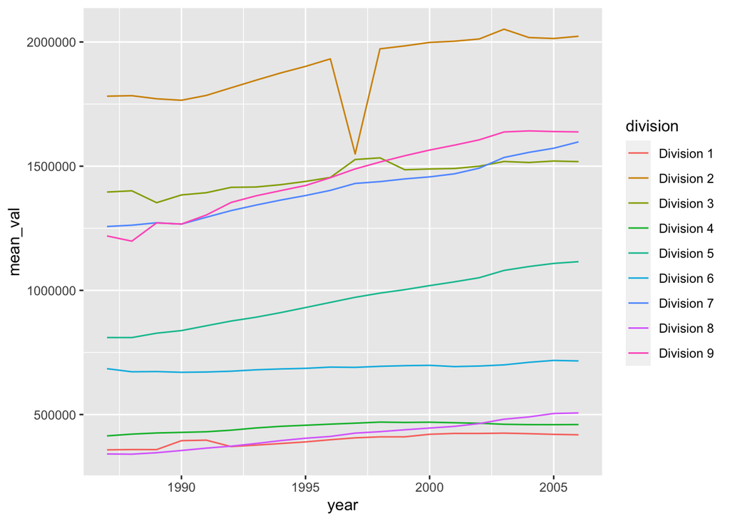

```r
plot(combined_data[[2]], var_name = "enrollment")
```

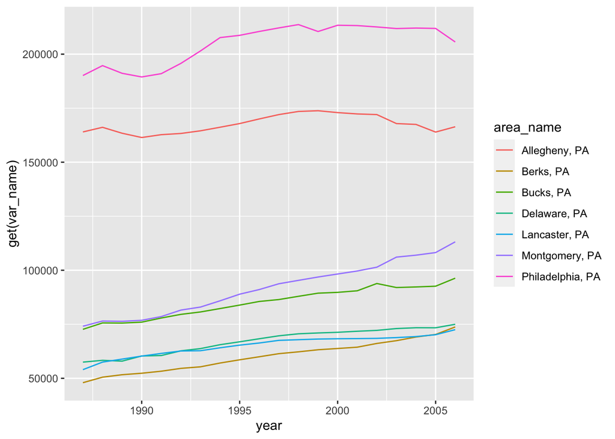

```r
plot(combined_data[[1]], select_state = "PA", position = "top", count_row = 7, var_name = "enrollment")
```

**Interpretation** : For the state of Pennsylvania, the top area is Philadelphia. Berks is the top 7th enrollment.

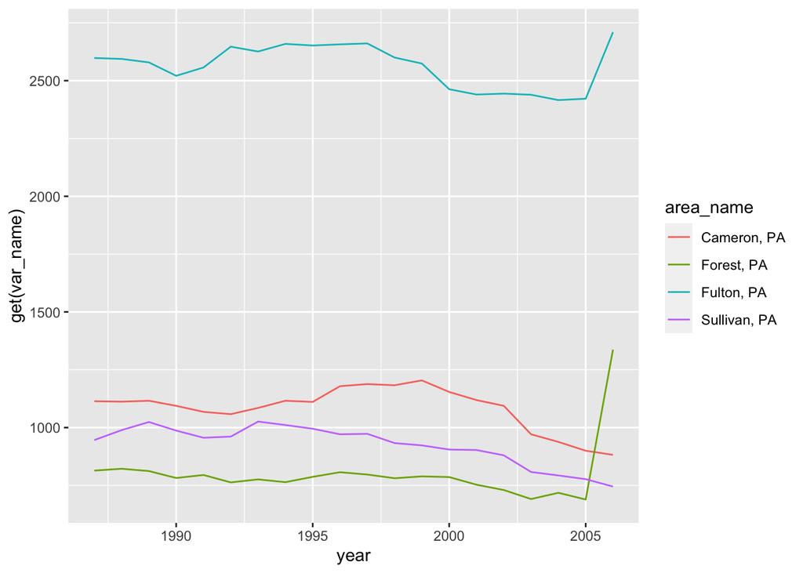

```r
plot(combined_data[[1]], select_state = "PA", position = "bottom", count_row = 4, var_name = "enrollment")
```

**Interpretation** : This plot shows the bottom 4 area of Pennsylvania. The 4 areas are Forest, Sullivan, Cameron, and Fulton.

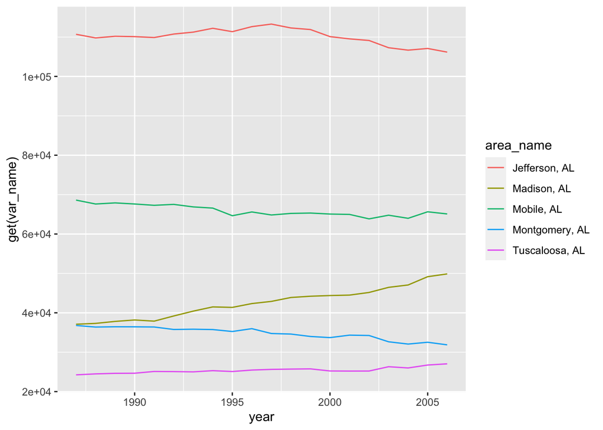

```r
plot(combined_data[[1]])
```

**Interpretation** : Here we just plot the state data with no filters. Hence, it takes the default settings and shows the top 5 areas of Alabama.

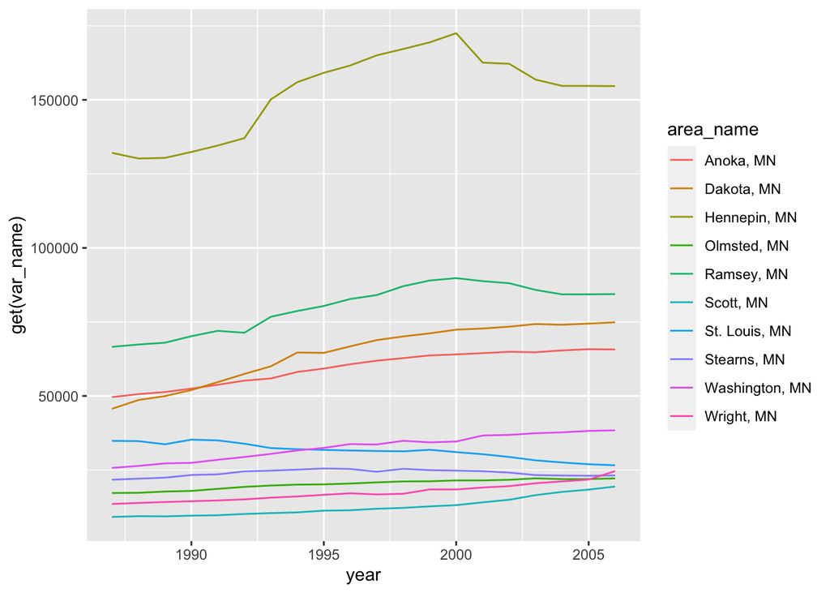

```r
plot(combined_data[[1]], select_state = "MN", position = "top", count_row = 10, var_name = "enrollment")
```

**Interpretation** : Here we display the top 10 areas by enrollment of Minnesota. The highest is Hennepin.

We now extend this processing to some other datasets :

```r
url3 <- "https://www4.stat.ncsu.edu/~online/datasets/PST01a.csv"
url4 <- "https://www4.stat.ncsu.edu/~online/datasets/PST01b.csv"
url5 <- "https://www4.stat.ncsu.edu/~online/datasets/PST01c.csv"
url6 <- "https://www4.stat.ncsu.edu/~online/datasets/PST01d.csv"

pst01a_data <- main(url3, var_name = "enrollment")
pst01b_data <- main(url4, var_name = "enrollment")
pst01c_data <- main(url5, var_name = "enrollment")
pst01d_data <- main(url6, var_name = "enrollment")
```

Combining all the datasets

```r
combined_data_1 <- combine_func(pst01a_data, pst01b_data)
combined_data_2 <- combine_func(combined_data_1, pst01c_data)
combined_data_final <- combine_func(combined_data_2, pst01d_data)
```

Plotting

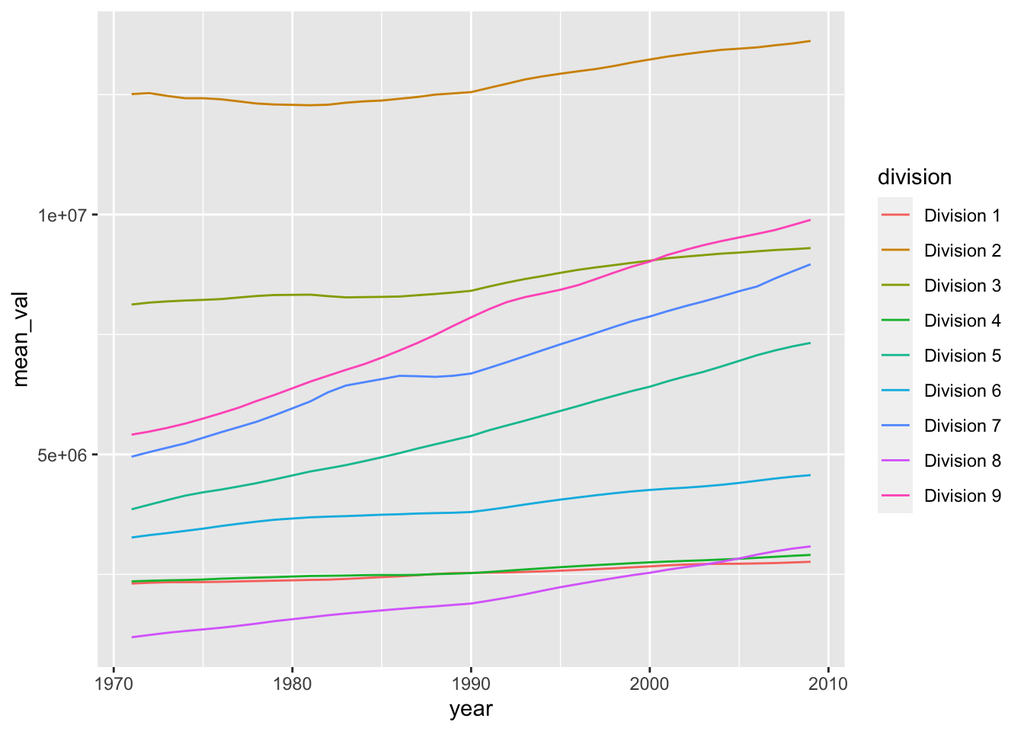

```r
plot(combined_data_final[[2]], var_name = "enrollment")
```

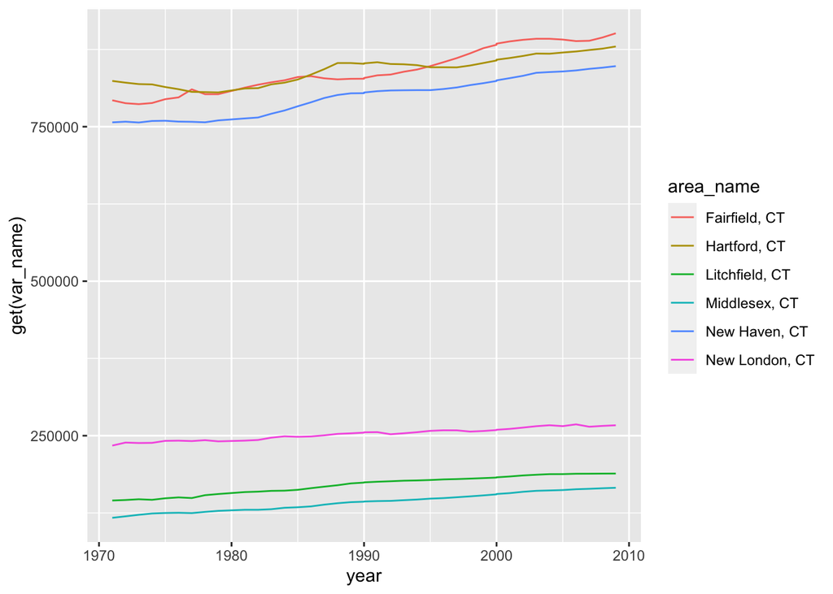

```r
plot(combined_data_final[[1]], select_state = "CT", position = "top", count_row = 6, var_name = "enrollment")
```

**Interpretation** : We plot the top 6 mean values of enrollment for Connecticut areas. Fairfield, New Haven, and Hartford show a pretty similar trend and have the top three mean enrollments over the years.

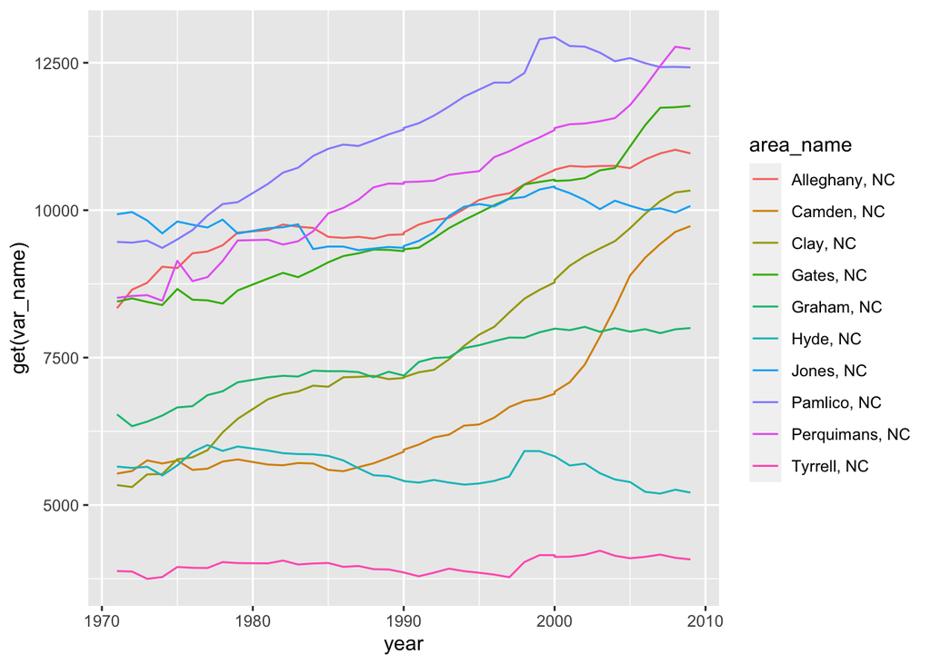

```r
plot(combined_data_final[[1]], select_state = "NC", position = "bottom", count_row = 10, var_name = "enrollment")
```

**Interpretation** : We now inspect the least 10 mean enrollment values for North Carolina. Tyrrel seems to be performing poorly with hardly any increase in mean enrollment value over the years.

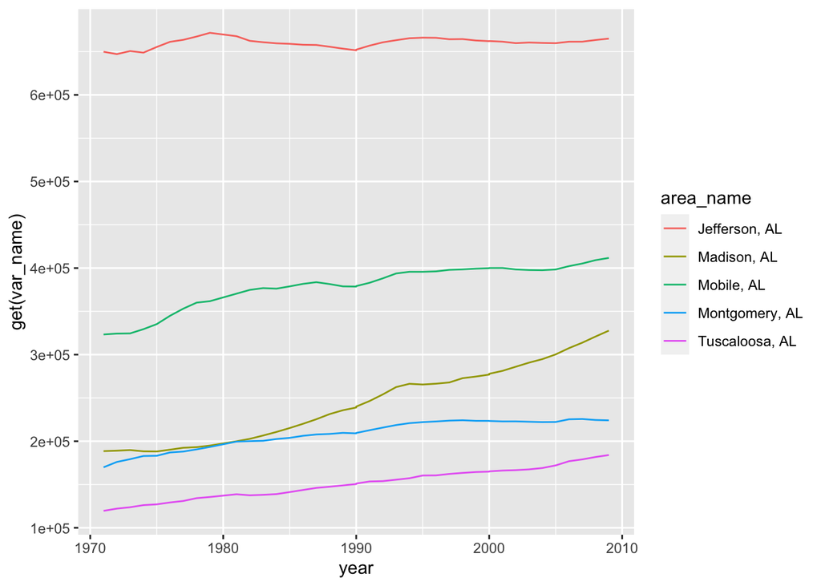

```r
plot(combined_data_final[[1]])
```

**Interpretation** : Here we just plot the state data with no filters. Hence, it takes the default settings and shows the top 5 areas of Alabama.

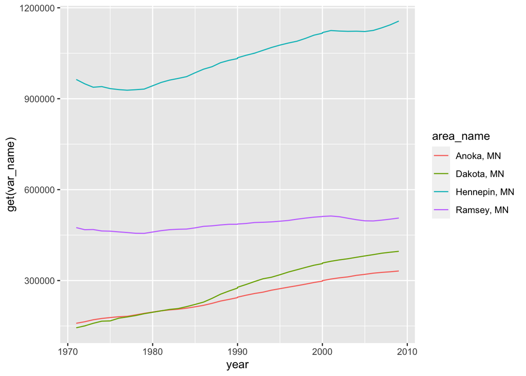

```r
plot(combined_data_final[[1]], select_state = "MN", position = "top", count_row = 4, var_name = "enrollment")
```

**Interpretation** : Here we just plot the state data for the top 4 enrollment mean values for Minnesota. Hennepin has the top mean enrollment value.